# RNA_seq_DEA

Mieke Vannahme

2025-06-10

# Installing packages

First we had to install the packages, that are needed for the analysis: DESeq2 and edgeR. The only way I could get the knit to work on my own computer was by adding the “BiocManager::install(”GenomeInfoDbData”, force = TRUE)“.

```r
if (!require("BiocManager", quietly = TRUE))
    install.packages("BiocManager")

BiocManager::install("DESeq2",force = TRUE)
BiocManager::install("edgeR",force = TRUE)
BiocManager::install("GenomeInfoDbData", force = TRUE)
```

We also needed to load the libraries for DESeq2 and edgeR.

```r
library(edgeR)
library(DESeq2)
```

# Preparing the data

To start the work we had to set our working directory to the directory, that contains the data.

```r
setwd('C:/Users/meixa/OneDrive/Dokumente/Helsinki/4_PracticalCourseinBioinformatics/RNA_Seq_report')
```

Next we loaded the file fileDesc.txt from the data folder into a dataframe called Coinfection.targets. This file contains the paths to the files containing the actual data. I chose the data from the inoculation with the beneficial fungus.

```r
Coinfection.targets<-read.delim("./data/fileDesc.txt")
```

To make the work easier for later we changes the rownames to the identifiers of our data. This way the rows are named after the samples and not 1, 2, 3, etc.

```r
rownames(Coinfection.targets)<-c("Sl1","Sl2","Sl3","Ctr1","Ctr2","Ctr3")
```

Then we loaded the actual RNA-Seq data to the dataframe Coinfection.orig and checked the dimensions of the dataset.

```r
Coinfection.orig <- readDGE(Coinfection.targets, header=F)
```

```r
dim(Coinfection.orig)
```

```
## [1] 51751     6
```

Next, we checked the first 6 rows of the data, which shows us the library sizes of the different samples.

```r
head(Coinfection.orig)
```

```
## An object of class "DGEList"
## $samples
##                files inoculation                description group lib.size
## Sl1   ./data/Sl1.txt          Sl Suillus luteus inoculation     1 17058954
## Sl2   ./data/Sl2.txt          Sl Suillus luteus inoculation     1 10329965
## Sl3   ./data/Sl3.txt          Sl Suillus luteus inoculation     1  9722676
## Ctr1 ./data/Ctr1.txt         Ctr                    Control     1 10763763
## Ctr2 ./data/Ctr2.txt         Ctr                    Control     1 10539029
## Ctr3 ./data/Ctr3.txt         Ctr                    Control     1 12251172
##      norm.factors
## Sl1             1
## Sl2             1
## Sl3             1
## Ctr1            1
## Ctr2            1
## Ctr3            1
##
## $counts
##             Samples
## Tags         Sl1 Sl2 Sl3 Ctr1 Ctr2 Ctr3
##   PITA_19277 158  81  86   90   80  329
##   PITA_36893   0   0   0    0    0    0
##   PITA_43071 228 122 145  128  133  127
##   PITA_31484   0   0   0    0    0    0
##   PITA_22913   0   0   0    0    0    0
##   PITA_43120  69  17  70   53   24   15
```

Afterwards, we stored the exact counts in the dataframe Coinfection.rawCount and checked the dimensions and the head of the dataset.

```r
Coinfection.rawCount <- Coinfection.orig$count
dim(Coinfection.rawCount)
```

```
## [1] 51751     6
```

```r
head(Coinfection.rawCount)
```

```
##             Samples
## Tags         Sl1 Sl2 Sl3 Ctr1 Ctr2 Ctr3
##   PITA_19277 158  81  86   90   80  329
##   PITA_36893   0   0   0    0    0    0
##   PITA_43071 228 122 145  128  133  127
##   PITA_31484   0   0   0    0    0    0
##   PITA_22913   0   0   0    0    0    0
##   PITA_43120  69  17  70   53   24   15
```

# Building the metadata

To build the metadata we define the sampletype as Control (Crt) and Sl-infection (Sl).

```r
sampletype <- factor(c(rep("Sl",3), rep("Ctr", 3)))
```

The dataframe meta defines, which sampletype the samples are.

```r
meta <- data.frame(sampletype, row.names = colnames(Coinfection.orig$count))
```

To make sure the columnnames in Coninfection.orig$count and the rownames in meta matche we check both of them individualy and via a comparison function.

```r
colnames(Coinfection.orig$count)
```

```
## [1] "Sl1"  "Sl2"  "Sl3"  "Ctr1" "Ctr2" "Ctr3"
```

```r
rownames(meta)
```

```
## [1] "Sl1"  "Sl2"  "Sl3"  "Ctr1" "Ctr2" "Ctr3"
```

```r
all(colnames(Coinfection.orig$count) %in% rownames(meta))
```

```
## [1] TRUE
```

# DESeq2 analysis

## Creating the DESeqDataset object

We create the DESeq2 dataset named dds, which has the counts and the metadata.

```r
library(DESeq2)
```

```r
dds <- DESeqDataSetFromMatrix(Coinfection.orig, colData = meta, design = ~ sampletype)
head(counts(dds))
```

```
##             Samples
## Tags         Sl1 Sl2 Sl3 Ctr1 Ctr2 Ctr3
##   PITA_19277 158  81  86   90   80  329
##   PITA_36893   0   0   0    0    0    0
##   PITA_43071 228 122 145  128  133  127
##   PITA_31484   0   0   0    0    0    0
##   PITA_22913   0   0   0    0    0    0
##   PITA_43120  69  17  70   53   24   15
```

Next, we use the function estimateSizeFactors() to generate size factors for median of ratios normalization.and checked the size factors in the following step.

```r
dds <- estimateSizeFactors(dds)
```

```r
sizeFactors(dds)
```

```
##       Sl1       Sl2       Sl3      Ctr1      Ctr2      Ctr3
## 1.5321926 0.9100622 0.8699987 0.9636806 0.8834023 1.0411417
```

Afterwards, we generated the normalized counts matrix and saved it in our local path.

```r
normalized_counts <- counts(dds, normalized=TRUE)
```

```r
write.csv(normalized_counts, file="./results/coinfection_normalized_counts_DESeq2.csv")
```

# Sample-level quality control

## Principal component analysis (PCA)

First, we had to transform our normalized counts in dds with the function rlog. The result is stored in rdl.

```r
rld <- rlog(dds, blind=TRUE)
```

Next, we plotted our data and saved the plot as a PDF on our computer.

```
## using ntop=500 top features by variance
```

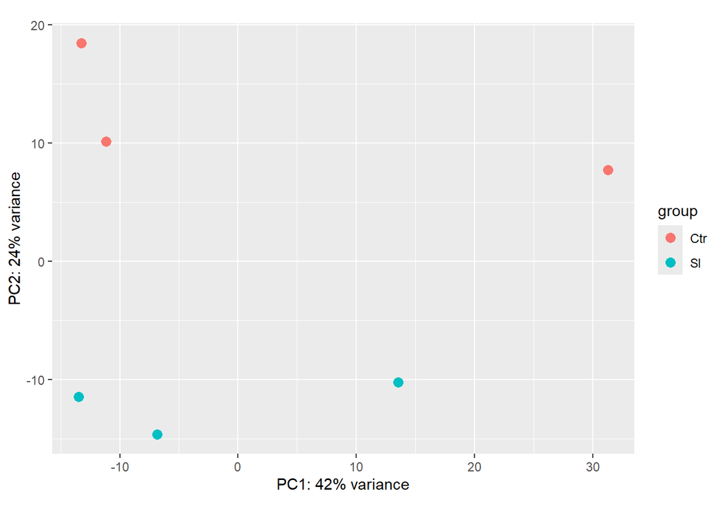

```r
plotPCA(rld, intgroup="sampletype")
```

```r
pdf("./results/PlotPCA_dds.pdf")
plotPCA(rld, intgroup="sampletype")
```

```
## using ntop=500 top features by variance
```

```r
dev.off()
```

Answers to exercise questions: 1) Two of the control group samples are quite similar, while the third is more different. The Sl group samples are relatively similar to each other. The two groups are very different from each other. 2) It is expected, that the two groups are very different from each other. It would be expected, that the samples within the control group would be more similar to each other. 3) The percent variance tells us how much of the varaince between the samples can be explained by the two components, respectively.

## Hierarchical Clustering Heatmap

First, we extracted the rlog matrix from rdl and stored it in rdl_mat. Then we computed the pairwise correlation values using the function cor() and stored them in rdl_cor.

```r
rld_mat <- assay(rld)
```

```r
rld_cor <- cor(rld_mat)
```

Afterwards, we checked the output of cor.

```r
head(rld_cor)
```

```
##            Sl1       Sl2       Sl3      Ctr1      Ctr2      Ctr3
## Sl1  1.0000000 0.9963348 0.9974919 0.9958090 0.9959248 0.9944159
## Sl2  0.9963348 1.0000000 0.9956896 0.9950146 0.9949172 0.9968032
## Sl3  0.9974919 0.9956896 1.0000000 0.9965046 0.9961772 0.9939391
## Ctr1 0.9958090 0.9950146 0.9965046 1.0000000 0.9967342 0.9944116
## Ctr2 0.9959248 0.9949172 0.9961772 0.9967342 1.0000000 0.9940599
## Ctr3 0.9944159 0.9968032 0.9939391 0.9944116 0.9940599 1.0000000
```

Then we checked the metadata for the samples.

```r
head(meta)
```

```
##      sampletype
## Sl1          Sl
## Sl2          Sl
## Sl3          Sl
## Ctr1        Ctr
## Ctr2        Ctr
## Ctr3        Ctr
```

To make the heatmap, we had to install the package heatmap.

```r
install.packages("pheatmap")
```

Then we loaded the heatmap library and plotted the heatmap.

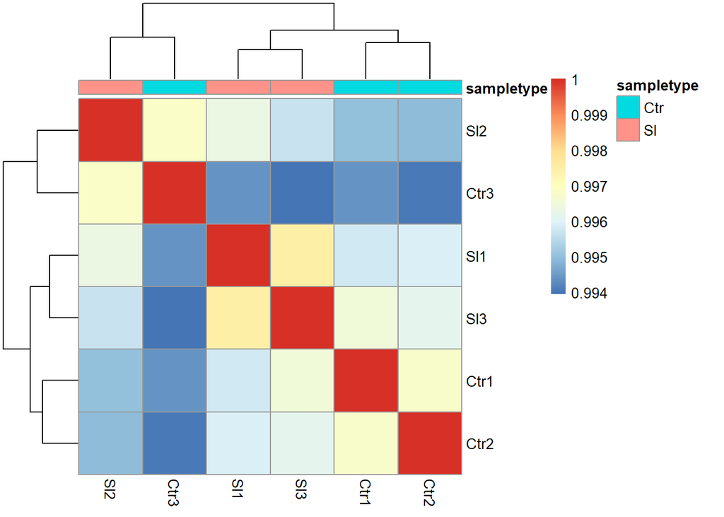

```r
library(pheatmap)
pheatmap(rld_cor, annotation = meta)
```

I was not happy with the colours and changed both the heatmap and the sampletype colours, based on instructions found online.

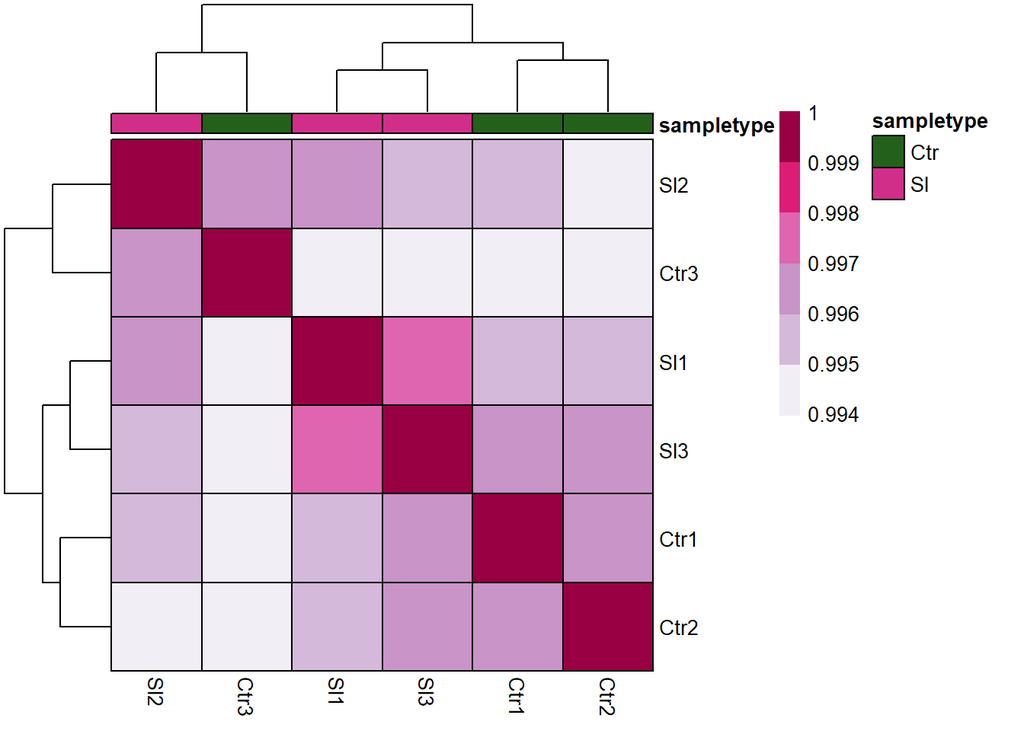

```r
heat.colors <- RColorBrewer::brewer.pal(6, "PuRd")
ann_colors = list(
  sampletype = c( Ctr = "#23611b", Sl = "#d12e8a")
)
pheatmap(rld_cor, annotation = meta, color = heat.colors, border_color=TRUE, fontsize = 10,
        fontsize_row = 10, height=20, annotation_colors = ann_colors)
```

I then saved the heatmap as a pdf. I added cellwidth and cellheight, to make the fields square in the PDF. I also saved the heatmap as a PNG because my PDF kept getting corrupted and would not open.

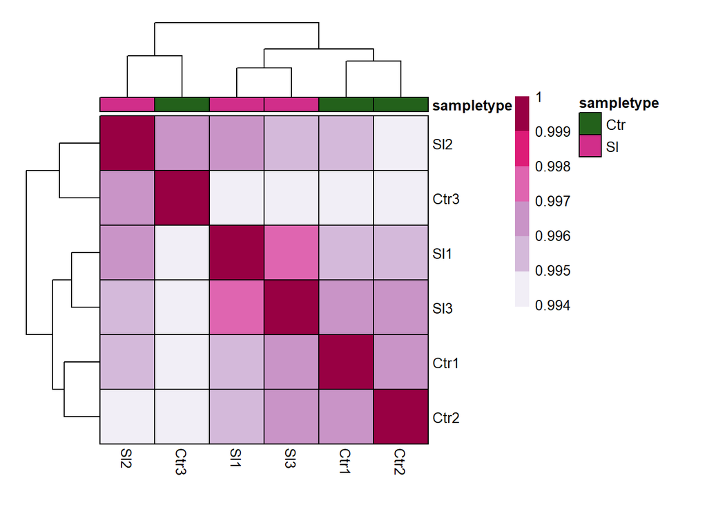

```r
pdf("./results/PlotHeatmap_dds.pdf")
heat.colors <- RColorBrewer::brewer.pal(6, "PuRd")
ann_colors = list(
  sampletype = c( Ctr = "#23611b", Sl = "#d12e8a")
)
pheatmap(rld_cor, annotation = meta, color = heat.colors, border_color=TRUE, fontsize = 10,
        fontsize_row = 10, height=20, cellwidth = 39, cellheight = 39,  annotation_colors = ann_colors)
```

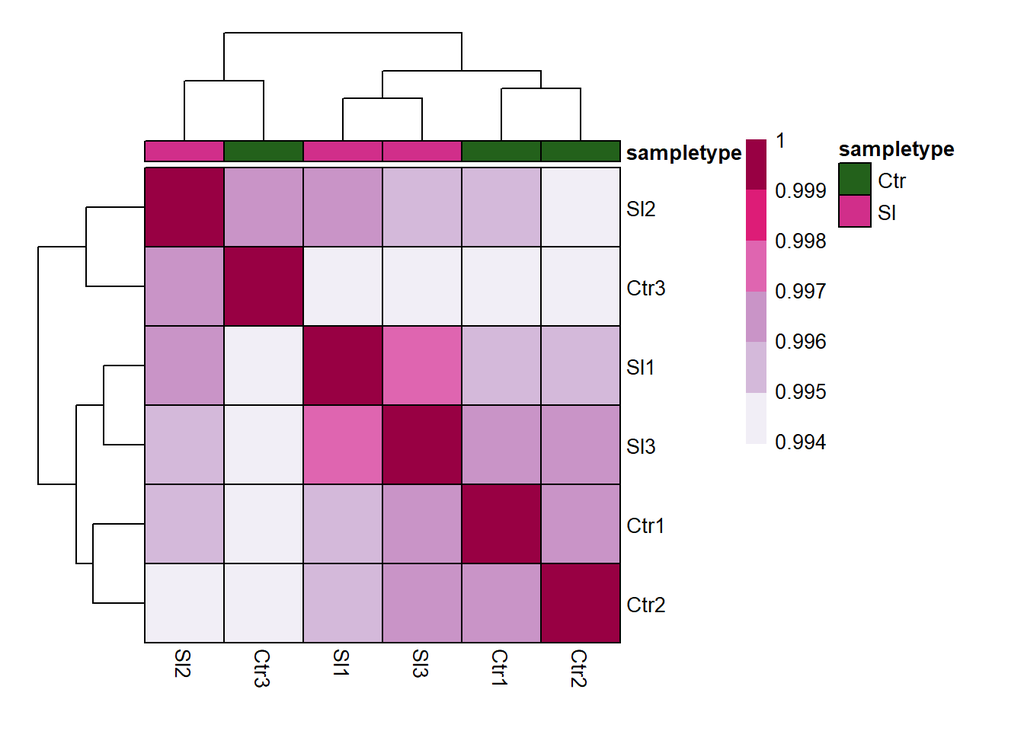

```r
png("./results/PlotHeatmap_dds.png")
heat.colors <- RColorBrewer::brewer.pal(6, "PuRd")
ann_colors = list(
  sampletype = c( Ctr = "#23611b", Sl = "#d12e8a")
)
pheatmap(rld_cor, annotation = meta, color = heat.colors, border_color=TRUE, fontsize = 10,
        fontsize_row = 10, height=20, cellwidth = 39, cellheight = 39,  annotation_colors = ann_colors)
```

# Differential expression analysis with EdgeR

## Preparing the data

First, we had to load the edgeR library and checked, we are in the right working directory.

```r
library(edgeR)
options(digits=3)
```

```r
getwd()
```

```
## [1] "C:/Users/meixa/OneDrive/Dokumente/Helsinki/4_PracticalCourseinBioinformatics/RNA_Seq_report"
```

Then, we loaded the file paths into infection.targets, changed the row names and checked the infection.targets.

```r
infection.targets<-read.delim("./data/fileDesc.txt")
```

```r
rownames(infection.targets)<-c("Sl1","Sl2","Sl3","Ctr1","Ctr2","Ctr3")
infection.targets
```

```
##                files inoculation                description
## Sl1   ./data/Sl1.txt          Sl Suillus luteus inoculation
## Sl2   ./data/Sl2.txt          Sl Suillus luteus inoculation
## Sl3   ./data/Sl3.txt          Sl Suillus luteus inoculation
## Ctr1 ./data/Ctr1.txt         Ctr                    Control
## Ctr2 ./data/Ctr2.txt         Ctr                    Control
## Ctr3 ./data/Ctr3.txt         Ctr                    Control
```

We then read and merged the text files into the dataframe infection and checked the dimensions and the head.

```r
infection <- readDGE(infection.targets, header=F)
dim(infection)
```

```
## [1] 51751     6
```

```r
head(infection)
```

```
## An object of class "DGEList"
## $samples
##                files inoculation                description group lib.size
## Sl1   ./data/Sl1.txt          Sl Suillus luteus inoculation     1 17058954
## Sl2   ./data/Sl2.txt          Sl Suillus luteus inoculation     1 10329965
## Sl3   ./data/Sl3.txt          Sl Suillus luteus inoculation     1  9722676
## Ctr1 ./data/Ctr1.txt         Ctr                    Control     1 10763763
## Ctr2 ./data/Ctr2.txt         Ctr                    Control     1 10539029
## Ctr3 ./data/Ctr3.txt         Ctr                    Control     1 12251172
##      norm.factors
## Sl1             1
## Sl2             1
## Sl3             1
## Ctr1            1
## Ctr2            1
## Ctr3            1
##
## $counts
##             Samples
## Tags         Sl1 Sl2 Sl3 Ctr1 Ctr2 Ctr3
##   PITA_19277 158  81  86   90   80  329
##   PITA_36893   0   0   0    0    0    0
##   PITA_43071 228 122 145  128  133  127
##   PITA_31484   0   0   0    0    0    0
##   PITA_22913   0   0   0    0    0    0
##   PITA_43120  69  17  70   53   24   15
```

## Raw count distribution

We mapped the read counts before filtering. For this we loaded the count data into the dataframe infection.rawCount and looked at the head.

```r
infection.rawCount <- infection$count
head(infection.rawCount)
```

```
##             Samples
## Tags         Sl1 Sl2 Sl3 Ctr1 Ctr2 Ctr3
##   PITA_19277 158  81  86   90   80  329
##   PITA_36893   0   0   0    0    0    0
##   PITA_43071 228 122 145  128  133  127
##   PITA_31484   0   0   0    0    0    0
##   PITA_22913   0   0   0    0    0    0
##   PITA_43120  69  17  70   53   24   15
```

We then installed the package ggplot2 for the visualization and loaded the library.

```r
install.packages("ggplot2")
```

```r
library(ggplot2)
```

We then plotted the data and saved it as a PDF.

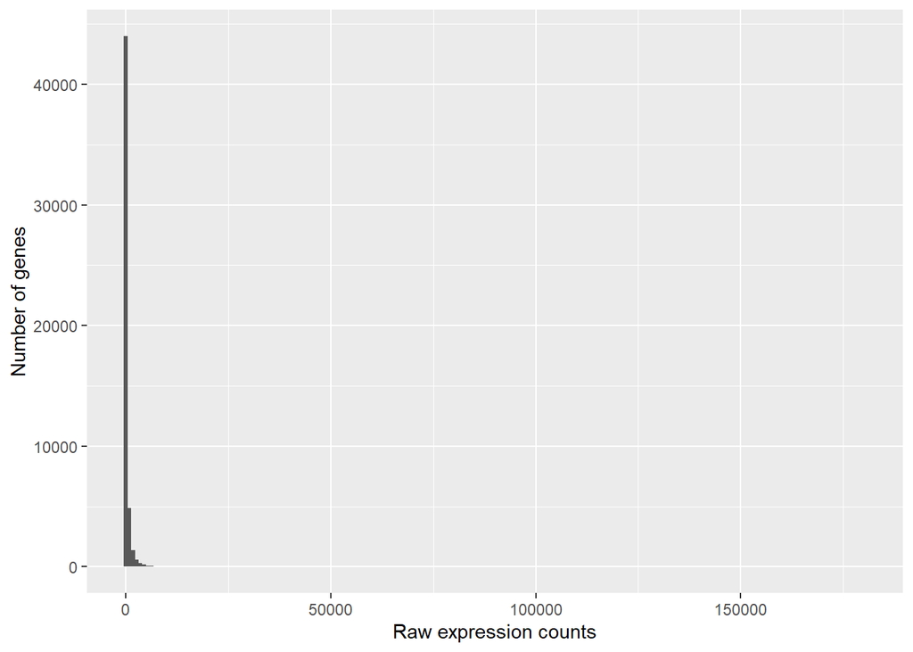

```r
ggplot(infection.rawCount) +
  geom_histogram(aes(x = Sl1), stat = "bin", bins = 200) +
  xlab("Raw expression counts") +
  ylab("Number of genes")
```

```r
  # xlim (0, 2000) + ylim(0, 5000)
```

```r
pdf("./results/count distribution.pdf", height=8, width=8)
ggplot(infection.rawCount) +
  geom_histogram(aes(x = Sl1), stat = "bin", bins = 200) +
  xlab("Raw expression counts") +
  ylab("Number of genes")
dev.off()
```

## Count normalization with TMM in EdgeR

We first exported the raw count table.

```r
write.csv(infection.rawCount, file="./results/infection.rawCounts.csv")
```

We then TMM normalized the CPM and stored them in the dataframe infection.normCPM. We checked the dimensions and the head of the dataframe.

```r
infection.normCPM <- cpm(calcNormFactors(infection))
dim(infection.normCPM)
```

```
## [1] 51751     6
```

```r
head(infection.normCPM)
```

```
##             Samples
## Tags               Sl1       Sl2       Sl3      Ctr1      Ctr2      Ctr3
##   PITA_19277  9.136745  7.754873  8.689959  8.159180  7.895631 27.604013
##   PITA_36893  0.000000  0.000000  0.000000  0.000000  0.000000  0.000000
##   PITA_43071 13.184670 11.680179 14.651676 11.604168 13.126486 10.655652
##   PITA_31484  0.000000  0.000000  0.000000  0.000000  0.000000  0.000000
##   PITA_22913  0.000000  0.000000  0.000000  0.000000  0.000000  0.000000
##   PITA_43120  3.990098  1.627566  7.073223  4.804851  2.368689  1.258542
```

We then exported the normalized counts as a csv file.

```r
write.csv(infection.normCPM, file="./results/infection.normCPM.csv")
```

## Filtering CPM and getting smaller size libraries

We filtered to keep the genes, that are expressed at at least one CPM in at least three libraries. We then checked how many genes were filtered out and kept.

```r
infection.filtered <- rowSums(cpm(infection)>1) >=3
```

```r
table(infection.filtered)
```

```
## infection.filtered
## FALSE  TRUE
## 26087 25664
```

We looked at the library sizes of the data before filtering.

```r
infection$samples$lib.size
```

```
## [1] 17058954 10329965  9722676 10763763 10539029 12251172
```

We then stored the filtered library sizes in the dataframe Inefection.

```r
Infection <- infection[infection.filtered,]
```

```r
colSums(Infection$counts)
```

```
##      Sl1      Sl2      Sl3     Ctr1     Ctr2     Ctr3
## 16979210 10294682  9678018 10713161 10489408 12191523
```

```r
dim(Infection)
```

```
## [1] 25664     6
```

We then updated the filtered library sizes.

```r
Infection$samples$lib.size <- colSums(Infection$counts)
Infection$samples
```

```
##                files inoculation                description group lib.size
## Sl1   ./data/Sl1.txt          Sl Suillus luteus inoculation     1 16979210
## Sl2   ./data/Sl2.txt          Sl Suillus luteus inoculation     1 10294682
## Sl3   ./data/Sl3.txt          Sl Suillus luteus inoculation     1  9678018
## Ctr1 ./data/Ctr1.txt         Ctr                    Control     1 10713161
## Ctr2 ./data/Ctr2.txt         Ctr                    Control     1 10489408
## Ctr3 ./data/Ctr3.txt         Ctr                    Control     1 12191523
##      norm.factors
## Sl1             1
## Sl2             1
## Sl3             1
## Ctr1            1
## Ctr2            1
## Ctr3            1
```

## Count normalization after filtering

We performed the TMM count normalization again after filtering and checked the libraries after normalization.

```r
Infection = calcNormFactors(Infection)
```

```r
Infection$samples
```

```
##                files inoculation                description group lib.size
## Sl1   ./data/Sl1.txt          Sl Suillus luteus inoculation     1 16979210
## Sl2   ./data/Sl2.txt          Sl Suillus luteus inoculation     1 10294682
## Sl3   ./data/Sl3.txt          Sl Suillus luteus inoculation     1  9678018
## Ctr1 ./data/Ctr1.txt         Ctr                    Control     1 10713161
## Ctr2 ./data/Ctr2.txt         Ctr                    Control     1 10489408
## Ctr3 ./data/Ctr3.txt         Ctr                    Control     1 12191523
##      norm.factors
## Sl1     1.0128617
## Sl2     1.0116518
## Sl3     1.0153346
## Ctr1    1.0235692
## Ctr2    0.9605744
## Ctr3    0.9776005
```

We then extracted the normalized CPM after filtering and saved them in a csv file.

```r
Infection.filtered.normCPM <-cpm(calcNormFactors(Infection))
```

```r
write.csv(Infection.filtered.normCPM, file="./results/Infection.filtered.normCPM.csv")
```

## Experimental design

We then set the treatment factor and described the experimental design.

```r
group<-factor(c('Sl','Sl','Sl',"Ctr","Ctr","Ctr"))
```

```r
Infection.design <- model.matrix(~group)
rownames(Infection.design)<-colnames(Infection$counts)
Infection.design
```

```
##      (Intercept) groupSl
## Sl1            1       1
## Sl2            1       1
## Sl3            1       1
## Ctr1           1       0
## Ctr2           1       0
## Ctr3           1       0
## attr(,"assign")
## [1] 0 1
## attr(,"contrasts")
## attr(,"contrasts")$group
## [1] "contr.treatment"
```

## Sample-level quality control by multidimensional scaling

We did a MDS plot , that shows the relative similarities of the samples and saved it as a png.

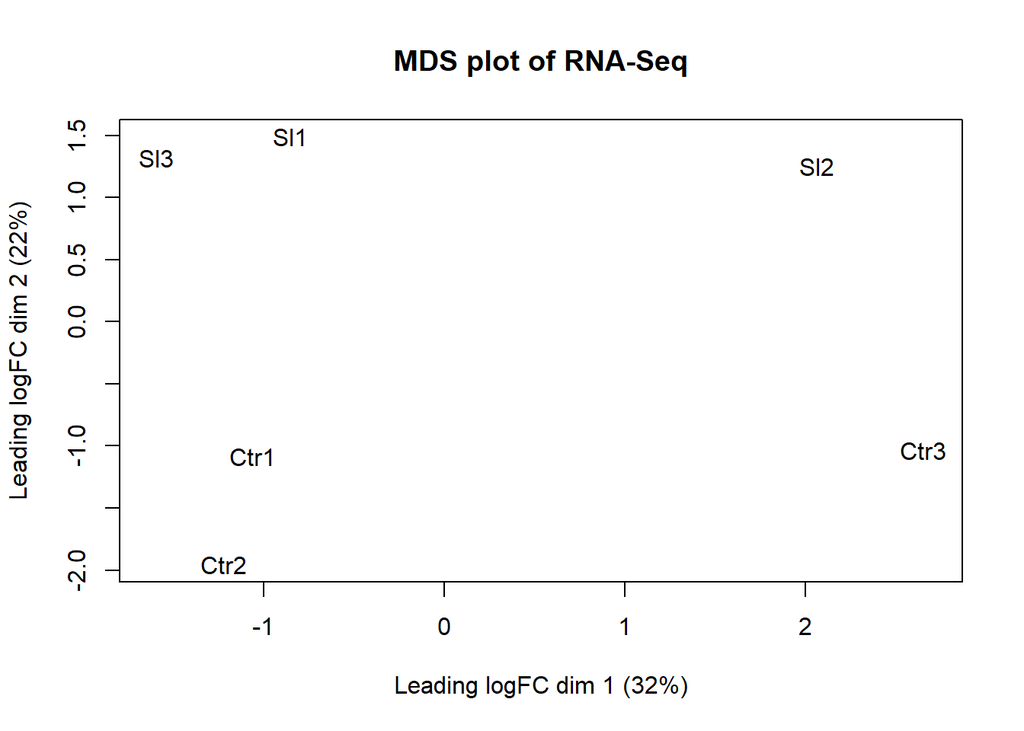

```r
plotMDS(Infection, main="MDS plot of RNA-Seq", labels=colnames(Infection$counts))
```

```r
png("./results/plotMDS.Infection.png", res=300, height=1800, width=1800)
plotMDS(Infection, main="MDS plot of Infection RNA-Seq", labels=colnames(Infection$counts))
dev.off()
```

## Estimating the common dispersion, trended dispersion, tagwise dispersion

We estimated the common dispersion,

```r
Infection <- estimateGLMCommonDisp(Infection, Infection.design)
```

the trended dispersion,

```r
Infection <- estimateGLMTrendedDisp(Infection, Infection.design)
```

and the tagwwise dispersion.

```r
Infection <- estimateGLMTagwiseDisp(Infection, Infection.design)
```

We then plotted the BCV against the avarage log of CPM.

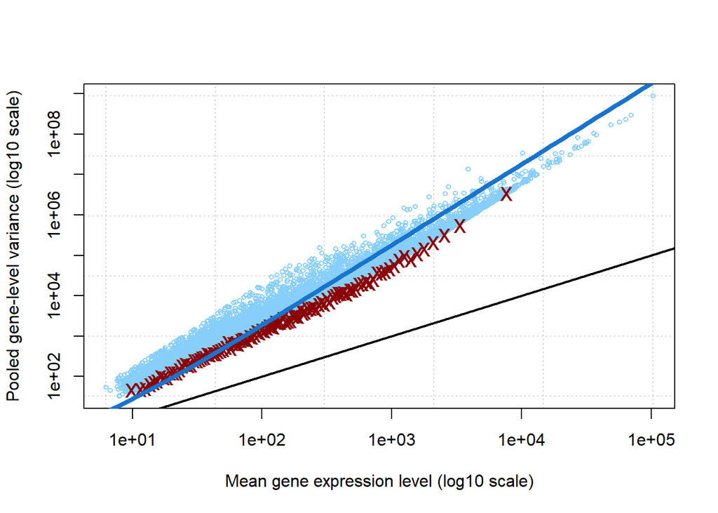

```r
plotMeanVar(Infection, show.tagwise.vars=T,NBline=T)
```

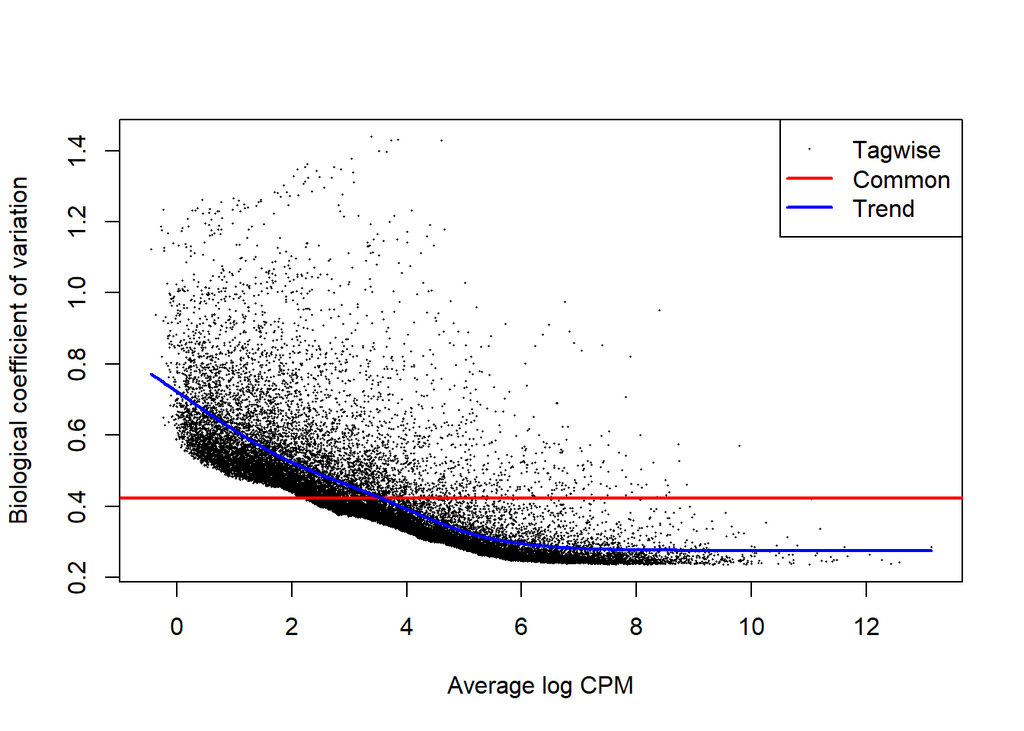

```r
plotBCV(Infection)
```

## Fit DGEList and design matrix to genewise GLM

We fitted the DGEList and the design matrix to the genewise GLM and checked the column names.

```r
Infection.fit <- glmFit(Infection, Infection.design)
colnames(Infection.fit)
```

```
## [1] "(Intercept)" "groupSl"
```

We then did a likelihhod test to compare the Crt and Sl groups ans stored the top tags in t1.

```r
lrt.Sl_vs_Ctr <- glmLRT(Infection.fit, coef=2)  # to compare Sl vs Ctr (Sl_vs_Ctr)
```

```r
t1<-topTags(lrt.Sl_vs_Ctr, n=nrow(Infection))
head(t1$table)
```

```
##                 logFC   logCPM        LR       PValue          FDR
## PITA_40477  12.054561 4.513429 198.28390 4.946890e-45 1.269570e-40
## PITA_11777  10.076755 2.568715  88.35239 5.477348e-21 7.028532e-17
## PITA_35366  -8.063622 2.397034  65.17655 6.847972e-16 5.333055e-12
## PITA_30776 -10.529350 3.006010  64.79473 8.312118e-16 5.333055e-12
## PITA_41141   9.287000 1.808497  59.46758 1.243256e-14 6.381385e-11
## PITA_51743  -5.872982 3.512267  51.52234 7.078709e-13 3.027800e-09
```

## Extracting number of differentially expressed genes¨

We first checked ho many genes are significantly up- and downregulated.

```r
summary(decideTests(lrt.Sl_vs_Ctr, adjust.method="BH", p.value=0.05))
```

```
##        groupSl
## Down        68
## NotSig   25551
## Up          45
```

We then checked how many genes were upregulated (with low strictness) and stored the results.

```r
nrow(subset(topTags(lrt.Sl_vs_Ctr, n=586)$table,  logFC > 0))
```

```
## [1] 222
```

```r
lrt.Sl_vs_Ctr_UP <- subset(topTags(lrt.Sl_vs_Ctr, n=586)$table, logFC > 0)
```

we then did the same step for the downregulated genes.

```r
nrow(subset(topTags(lrt.Sl_vs_Ctr, n=586)$table,  logFC < 0))
```

```
## [1] 364
```

```r
lrt.Sl_vs_Ctr_DW <- subset(topTags(lrt.Sl_vs_Ctr, n=586)$table, logFC < 0)
```

## Differentially expressed transcripts tags

We stored the tags of the differentially expressed transcripts.

```r
DEtags.lrt.Sl_vs_Ctr <- rownames(Infection)[as.logical(decideTests(lrt.Sl_vs_Ctr, adjust.method="BH", p.value=0.05))]
```

We then exported the up- and downregulated genes in two separate csv files.

```r
write.csv(lrt.Sl_vs_Ctr_UP, file="./results/lrt.Sl_vs_Ctr_UP.csv")
write.csv(lrt.Sl_vs_Ctr_DW, file="./results/lrt.Sl_vs_Ctr_DW.csv")
```

Then we assigned colour to the transcripts for the plotting. First all transcripts were defined as grey.

```r
Infection.colSlvsCtr = rep('grey55', nrow(Infection))
```

We then assigned the colour red for upregulated genes and blue for downregulated genes.

```r
Infection.colSlvsCtr[lrt.Sl_vs_Ctr$table$PValue < 0.05 & lrt.Sl_vs_Ctr$table$logFC >0 ] <- "red"
Infection.colSlvsCtr[lrt.Sl_vs_Ctr$table$PValue < 0.05 & lrt.Sl_vs_Ctr$table$logFC <0 ] <- "blue"
```

We then created a smear plotwith adjustments on the y-axis label.

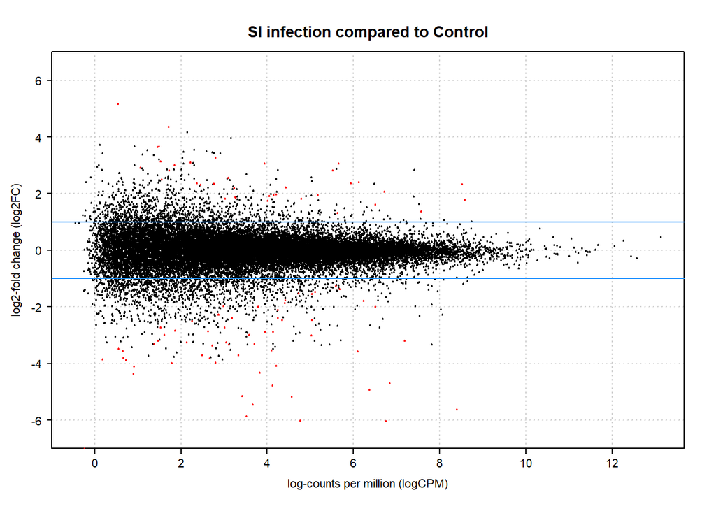

```r
par(omi=c(0.1,0.1,0.1,0.1), las=1, cex=0.5, mgp=c(3,1,0), cex.main=1.8, cex.lab=1.4, cex.axis=1.4)
plotSmear(lrt.Sl_vs_Ctr, de.tags=DEtags.lrt.Sl_vs_Ctr, xlab="log-counts per million (logCPM)", ylab="log2-fold change (log2FC)", main="Sl infection compared to Control", pch=19, cex=0.4, smearWidth=0.5, panel.first=grid(), smooth.scatter=FALSE, ylim=c(-7,7), yaxs="i")
abline(h=c(-1,1),col="dodgerblue")
```

We then changed the colour of the DE tags.

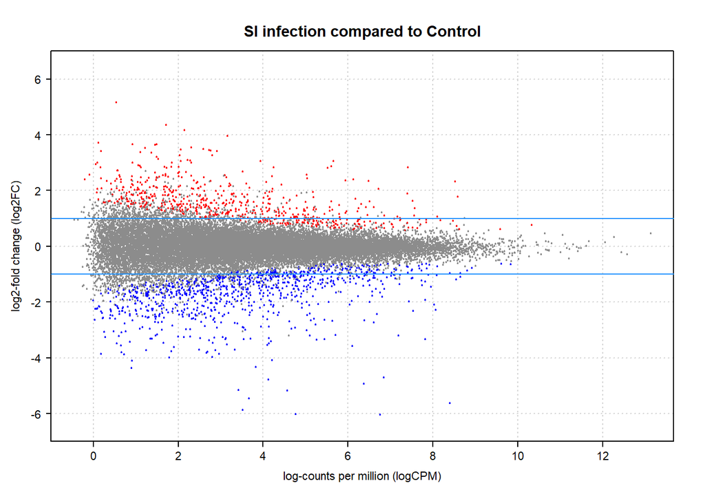

```r
par(omi=c(0.1,0.1,0.1,0.1), las=1, cex=0.5, mgp=c(3,1,0), cex.main=1.8, cex.lab=1.4, cex.axis=1.4)
plotSmear(lrt.Sl_vs_Ctr, xlab="log-counts per million (logCPM)", ylab="log2-fold change (log2FC)", main="Sl infection compared to Control", smearWidth=0.5, pch=21, cex=0.4, deCol="red", col=Infection.colSlvsCtr, ylim=c(-7,7), yaxs="i")
abline(h=c(-1,1),col="dodgerblue")
```

Finally, we exported the plot of differentialy expressed genes as a png.

```r
png("./results/plotSmear.InfectionRNAseq.png", res=300, height=1800, width=1800)
par(omi=c(0.1,0.1,0.1,0.1), las=1, cex=0.5, mgp=c(3,1,0), cex.main=1.8, cex.lab=1.4, cex.axis=1.4)
plotSmear(lrt.Sl_vs_Ctr, xlab="log-counts per million (logCPM)", ylab="log2-fold change (log2FC)", main="Sl infection compared to Control", smearWidth=0.5, pch=21, cex=0.4, deCol="red", col=Infection.colSlvsCtr, ylim=c(-7,7), yaxs="i")
abline(h=c(-1,1),col="dodgerblue")
dev.off()
```